Daniel van Strien

# Image labeling vs classification models

Comparing the loss functions of label and classification models

Oct 12, 2020 • 17 min read

models labels loss functions

- Image Classification vs Image Labeling
  - Sorting through family photos
- CrossEntropyLoss vs BCEWithLogitsLoss
  - CrossEntropyLoss
  - BCEWithLogitsLoss
- Exploring CrossEntropyLoss
  - What is softmax doing?
    - exp[source]
  - So what is different here?
- Exploring BCEWithLogitsLoss
- Discussion
  - Labeling in a Digital Humanities/GLAM context

The 'hello world' example for introducing deep learning based computer vision often involves classifying images as 🐶 or 🐱. An alternative approach to classifying images is to instead apply labels. This is usually introduced in the context of multi-label classification i.e. where an image can have more than one label. In this blog post I discuss some of the differences between these two approaches, specifically the difference in loss functions, and how these two approaches might work better depending on the application. The post starts with a conceptual overview of the differences between these two approaches, before showing the different loss functions and then moving to a practical example of training these two different types of model.

## Image Classification vs Image Labeling

In a classification model, an input can have only one label. This could be one of a few or one of a hundred, regardless of the number of potential classes, it is assumed that the input only belongs to one of these. With a model that applies labels this is not true an input can have one, multiple or no labels.

### Sorting through family photos

We can use an analogy to illustrate the difference between these two approaches. Let's say you were sorting through some old family photographs. You might "classify" the photos into one (and only one) of two photo albums, depending on whether they are black-and-white or colour. This would be comparable to using a classification model since each photo will go into exactly one of these two albums - a photo cannot be both simultaneously colour *and* black-and-white, and it cannot be neither colour *nor* black-and-white.

You may at the same time also want to make it easier to find photos of particular people in your family. You could do this by assigning labels to each photo, indicating or "tagging" the family members who appear in the photo. In this case, a photo may have one label (a photo of your sister), more than one label (a photo of your sister *and* aunt), or it may have no labels (a photograph of a landscape taken on a holiday). This would be analogous to a multi-label classification model.

The choice between using a model which performs classification or a model which assigns labels should be considered in relation to the role your model has. It is also useful to look a little bit more closely as how these different types of models work under the hood.

## CrossEntropyLoss vs BCEWithLogitsLoss

When we create a model which does classifications or applies labels, the distinction, if using the same data is that they use different loss functions.

A classification model will use a variant of Cross Entropy Loss whilst the label model will use a BCE with Logits Loss. We'll see how this is inferred by fastai below but fore now take my word for it...

Let's take a look at a snippet of the Pytorch docs for each of these loss functions

### CrossEntropyLoss

> This criterion combines nn.LogSoftmax() and nn.NLLLoss() in one single class. It is useful when training a classification problem with C classes. If provided, the optional argument weight should be a 1D Tensor assigning weight to each of the classes. This is particularly useful when you have an unbalanced training set. [Read more](https://pytorch.org/docs/stable/generated/torch.nn.CrossEntropyLoss.html#crossentropyloss)

### BCEWithLogitsLoss

> This loss combines a Sigmoid layer and the BCELoss in one single class. This version is more numerically stable than using a plain Sigmoid followed by a BCELoss as, by combining the operations into one layer, we take advantage of the log-sum-exp trick for numerical stability. [Read more](https://pytorch.org/docs/stable/generated/torch.nn.BCEWithLogitsLoss.html?highlight=bcewithlogitsloss)

Let's see what these do to some activations. First we'll import required packages

```python
import torch.nn as nn
import numpy as np
import torch
```

# Exploring CrossEntropyLoss

We can create some fake activations. To start we'll just consider one output with three classes. We'll start with one to keep things simple for now.

```python
one_act = torch.randn((1, 3)) * 1
one_act
```

[output not shown]

We can think of these activations as probabilities for one of three classes. Let's see what these sum to.

```python
one_act.sum()
```

```
tensor(1.0875)
```

```python
softmax_acts = torch.softmax(one_act, dim=1)
softmax_acts
```

```
tensor([[0.4525, 0.0381, 0.5093]])
```

You can probably already see how this has changed the nature of these activations. Let's call sum on these outputs again.

```python
softmax_acts.sum()
```

```
tensor(1.)
```

We now have a sum of 1! We can now treat this as the probability of an input image belonging to a particular class. We could then call argmax to find out which class the model is most confident about and use that as our prediction.

```python
softmax_acts.argmax(dim=1)
```

```
tensor([2])
```

One of the potential issues that was mentioned about using a classification model was that it doesn't account for ambiguities in the labels very well.

### What is softmax doing?

Digging into what `softmax` does in a little bit more detail will show what is going on here.

First lets see what softmax actually does, I'll skip the LaTeX formula from Wikepedia because it makes is look much scarier than the [Python code example](https://en.wikipedia.org/wiki/Softmax_function#Example):

```python
a = [1.0, 2.0, 3.0, 4.0, 1.0, 2.0, 3.0]
np.exp(a) / np.sum(np.exp(a))
```

```
array([0.02364054, 0.06426166, 0.1746813 , 0.474833  , 0.02364054,
       0.06426166, 0.1746813 ])
```

This is much easier for me to parse compared to the Greek. Let's look at the different parts. Working with one set of activations again:

```python
one_act
```

```
tensor([[ 1.1479, -1.3265,  1.2661]])
```

Starting from `np.exp(a)` we can do this in Pytorch like:

```python
one_act.exp()
```

```
tensor([[3.1515, 0.2654, 3.5471]])
```

We can convert the rest of the numpy code as follows

```python
one_act.exp().sum(dim=1)
```

```
tensor([6.9641])
```

Putting it all together we get

```python
(one_act.exp() /one_act.exp().sum(dim=1)).sum(dim=1)
```

```
tensor([1.])
```

This seems to work as expected, i.e. we get the probabilities to sum to 1. To make it clearer what's going on though, it's useful to look a little more closely at the difference using `exp` makes. Let's import the standard python version of `exp` and check the docs.

```python
from math import exp
doc(exp)
```

`exp`[source]

> `exp`(**`x`**)

Return e raised to the power of x.

What difference does using the exponent make? We'll use a simple array of values to keep things simple

```python
x = np.array([1,2,4,1])
x
```

```
array([1, 2, 4, 1])
```

Now if we want these to be converted to probabilities for different classes we need them to sum to 1. We could just do this by dividing each element by the sum.

```python
x/x.sum()
```

```
array([0.125, 0.25 , 0.5  , 0.125])
```

We can confirm this add to 1

```python
(x/x.sum()).sum()
```

```
1.0
```

Now this seems to work to get us probabilities for each class. Let's compare doing the same thing but using `exp` to create exponents of the inputs

```python
np.exp(x)/np.sum(np.exp(x))
```

```
array([0.04031637, 0.10959126, 0.80977599, 0.04031637])
```

Again we get an array of probabilities, let's confirm they add to one.

```python
one_act.exp()/one_act.exp().sum(dim=1)
```

[output not shown]

### So what is different here?

Let's put the two arrays next to each other so we can compare the values for each index

```python
np.exp(x)/ np.sum(np.exp(x)), (x/ x.sum())
```

```
(array([0.04031637, 0.10959126, 0.80977599, 0.04031637]),
 array([0.125, 0.25 , 0.5  , 0.125]))
```

Other than the difference in decimals, you will probably notice that when we use exponent, some labels for a class have been pushed much higher. Index `2` is `0.80` when we use `exp` and only `0.5` when we don't use the exponent. This is an important difference here. By using the magic properties of $e$ we 'push' one probability to be higher than the others.

This property is useful when we have a clear distinction between classes. If we were predicting handwritten digits there (should) only be one correct answer. In this case having one class prediction being pushed much higher would be a good thing.

If however, we have labels which are more ambiguous, this would be less of a desirable property. Even if we try and capture ambiguity by using the raw probabilities of the labels, rather than taking the `argmax` value, the numerical properties of the softmax function mean that it likely that one label value will be pushed higher than the others.

We'll look at a practical example later on to illustrate this. Let's now quickly compare our other loss function

# Exploring BCEWithLogitsLoss

As a reminder

> This loss combines a Sigmoid layer and the BCELoss in one single class.

The part here that we are particularly interested in is the `Sigmoid`. Let's use `one_acts` again

```python
one_act
```

```
tensor([[ 1.1479, -1.3265,  1.2661]])
```

As a reminder sigmoid function can be plotted as

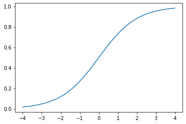

You'll probably be familiar with sigmoid as one of the potential activations functions you can use in the a neural network. The property we care about is that it squishes inputs into a value between 0 and 1. Let's do this for our activations

```python
torch.sigmoid(one_act)
```

```
tensor([[0.7591, 0.2097, 0.7801]])
```

We can see that all our values have been pushed between 0 and 1. However, we can also see they don't sum to 1.

```python
torch.sigmoid(one_act).sum()
```

```
tensor(1.7489)
```

What we have here is a probability for each label which is *independent* of the probability of the other labels. The sigmoid function makes sure the activations for each label becomes a probability but it doesn't make sure that all of the labels probabilities sum to 1. Looking at a practical example using fastai might illustrate this difference.

We'll work with some images taken from 19th Century books, the specific images in this case don't matter to do much

We'll import fastai and then put images from two folders 'building' and 'coat' into a Pandas DataFrame.

```python
from fastai.vision.all import *
```

```python
files = get_image_files('data/cv_workshop_exercise_data/', folders=['building', 'coat'])
df = pd.DataFrame(files.items, columns=['fname'])
df['class_label'] = df['fname'].apply(lambda x: x.parts[2])
df['class_label'].value_counts()
```

```
building    44
coat        26
Name: class_label, dtype: int64
```

We can see we have two possible classes `building` and `coat`. First we'll load these into fastai as a classification model.

```python
dls_classification = ImageDataLoaders.from_df(df,fn_col='fname',valid_pct=0.4, label_col='class_label', item_tfms=Resize(128, ResizeMethod.Squish), bs=8,num_workers=0)
```

[figure not shown]

```python
dls_classification.show_batch()
```

You'll see that building refers to a building, whilst a coat refers to a coat of arms. Let's now load this data into fastai

```python
learn = cnn_learner(dls_classification, resnet18, metrics=[accuracy, F1Score()])
```

Often if we pass fastai a dataloader it will be able to infer the correct loss function based on this data. we can access this using the `loss_func` attribute.

```python
learn.loss_func
```

```
FlattenedLoss of CrossEntropyLoss()
```

As promised this is a variant on the CrossEntropyLoss we saw earlier. Let's now fit it for a bit.

```python
learn.fit(5)
```

| epoch | train_loss | valid_loss | accuracy | f1_score | time |
| --- | --- | --- | --- | --- | --- |
| 0 | 1.023169 | 0.786303 | 0.785714 | 0.769231 | 00:03 |
| 1 | 0.721281 | 0.576258 | 0.821429 | 0.814815 | 00:03 |
| 2 | 0.477446 | 0.339626 | 0.821429 | 0.782609 | 00:04 |
| 3 | 0.423173 | 0.331097 | 0.821429 | 0.782609 | 00:03 |
| 4 | 0.351390 | 0.239433 | 0.857143 | 0.818182 | 00:03 |

Now we have a model, we'll grab the predictions

```python
acts, _ = learn.get_preds()
acts
```

```
tensor([[9.9795e-01, 2.0519e-03],
        [9.9811e-01, 1.8889e-03],
        [9.9911e-01, 8.8577e-04],
        [9.9680e-01, 3.2038e-03],
        [6.5879e-01, 3.4121e-01],
        [1.2512e-04, 9.9987e-01],
        [9.9734e-01, 2.6599e-03],
        [9.8866e-01, 1.1341e-02],
        [9.2739e-01, 7.2608e-02],
        [9.8336e-01, 1.6643e-02],
        [1.7059e-01, 8.2941e-01],
        [9.9899e-01, 1.0067e-03],
        [5.2081e-01, 4.7919e-01],
        [4.9184e-03, 9.9508e-01],
        [9.9930e-01, 7.0161e-04],
        [1.0109e-04, 9.9990e-01],
        [9.9533e-01, 4.6670e-03],
        [3.6834e-02, 9.6317e-01],
        [5.7022e-06, 9.9999e-01],
        [9.8635e-01, 1.3647e-02],
        [2.1610e-01, 7.8390e-01],
        [2.3512e-02, 9.7649e-01],
        [2.9994e-01, 7.0006e-01],
        [4.2728e-02, 9.5727e-01],
        [9.8494e-01, 1.5062e-02],
        [1.4194e-01, 8.5806e-01],
        [6.8620e-01, 3.1380e-01],
        [7.3493e-01, 2.6507e-01]])
```

These are the predictions for each class, let's confirm these all sum to 1.

```python
acts.sum(dim=1)
```

```
tensor([1.0000, 1.0000, 1.0000, 1.0000, 1.0000, 1.0000, 1.0000, 1.0000, 1.0000,
        1.0000, 1.0000, 1.0000, 1.0000, 1.0000, 1.0000, 1.0000, 1.0000, 1.0000,
        1.0000, 1.0000, 1.0000, 1.0000, 1.0000, 1.0000, 1.0000, 1.0000, 1.0000,
        1.0000])
```

If we look at the max for each probability we'll see they tend to be high.

```python
acts.max(dim=1)[0]
```

```
tensor([0.9979, 0.9981, 0.9991, 0.9968, 0.6588, 0.9999, 0.9973, 0.9887, 0.9274,
        0.9834, 0.8294, 0.9990, 0.5208, 0.9951, 0.9993, 0.9999, 0.9953, 0.9632,
        1.0000, 0.9864, 0.7839, 0.9765, 0.7001, 0.9573, 0.9849, 0.8581, 0.6862,
        0.7349])
```

Looking at the mean, max and min:

```python
acts.max(dim=1)[0].mean(), acts.max(dim=1)[0].max(), acts.max(dim=1)[0].min(),
```

```
(tensor(0.9113), tensor(1.0000), tensor(0.5208))
```

This is desirable if the input we are trying to label does neatly fit the categories but if we are trying to label something which is more ambiguous then this might be less useful. A particular case where this certainty might not be so helpful is when your model may possibly face out of domain images, i.e. see things it hasn't seen before and for which none of the classes it is trying to predict should apply. Let's load a new dataset of images of people.

```python
people = get_image_files('data/cv_workshop_exercise_data/', folders='people')
people
```

```
(#38) [Path('data/cv_workshop_exercise_data/people/000001929_03_000249_2_De Aardbol  Magazijn van hedendaagsche land  en volkenkunde     Met platen en kaarten  [Deel 4 9 by P  H  W ]_1839.jpg'),Path('data/cv_workshop_exercise_data/people/000194796_0_000133_1_Historical Collections     relating to th…
```

[figure not shown]

```python
PILImage.create(people[5])
```

What happens if we predict one of these:

```python
learn.predict(PILImage.create(people[5]))
```

```
('building', tensor(0), tensor([0.9916, 0.0084]))
```

It's predict that Torstenson is a building with a probability of 99% certainty! Let's look at some more

```python
preds, _ = learn.get_preds(dl=learn.dls.test_dl(people))
```

now we have a bunch of predictions let's get the max value. i.e. the probability for the label it predicted and see what the min, max and median is:

```python
preds.max(dim=1)[0].min(), preds.max(dim=1)[0].max(), preds.max(dim=1)[0].median()
```

```
(tensor(0.5288), tensor(1.0000), tensor(0.9765))
```

Although the min is fairly low, the median value is pretty confidently predicting a wrong label. Let's see how this differs if we instead use a 'label model'. fastai expects labels to be inside a list, we can create a new column which puts our classes inside a list.

```python
df['label'] = df['class_label'].apply(lambda x: [x])
```

We'll now load in the data. The only difference here is that we specify a `y_block`, this forces fastai to choose the correct loss function.

[figure not shown]

```python
dls_label = ImageDataLoaders.from_df(df,fn_col='fname',
                                     valid_pct=0.4,
                                     label_col='label',
                                     y_block=MultiCategoryBlock,
                                     item_tfms=Resize(128, ResizeMethod.Squish),
                                     bs=8,
                                     num_workers=0)
dls_label.show_batch()
```

If we now create the learner, we'll see a different loss function

```python
label_learn = cnn_learner(dls_label, resnet18, metrics=[F1ScoreMulti()])
label_learn.loss_func
```

```
FlattenedLoss of BCEWithLogitsLoss()
```

Again we'll fit for a while

```python
label_learn.fit(5)
```

| epoch | train_loss | valid_loss | f1_score | time |
| --- | --- | --- | --- | --- |
| 0 | 0.979886 | 1.107939 | 0.520422 | 00:03 |
| 1 | 0.742499 | 0.530855 | 0.749681 | 00:03 |
| 2 | 0.540384 | 0.294314 | 0.858553 | 00:03 |
| 3 | 0.428714 | 0.197953 | 0.874603 | 00:03 |
| 4 | 0.358649 | 0.157847 | 0.973684 | 00:03 |

Now we'll grab some predictions again

```python
preds, _ = label_learn.get_preds()
preds
```

```
tensor([[9.8592e-01, 2.2629e-02],
        [5.0721e-01, 1.0558e-01],
        [9.9954e-01, 1.4539e-02],
        [2.6342e-01, 9.7471e-01],
        [9.9732e-01, 3.8691e-04],
        [1.0064e-02, 9.9507e-01],
        [1.5311e-02, 9.7020e-01],
        [2.2675e-03, 9.9944e-01],
        [9.7902e-01, 2.7719e-02],
        [6.0582e-01, 1.2015e-01],
        [7.7181e-02, 9.9448e-01],
        [9.8096e-01, 5.7364e-03],
        [8.2864e-01, 4.2955e-01],
        [9.0980e-01, 1.1982e-02],
        [9.6249e-01, 1.3159e-02],
        [2.3728e-01, 6.0858e-01],
        [9.9327e-01, 4.9904e-03],
        [9.1160e-04, 9.8218e-01],
        [9.7016e-01, 2.2057e-03],
        [9.8055e-01, 1.9247e-02],
        [8.3900e-01, 2.7438e-01],
        [4.3518e-01, 1.6118e-01],
        [6.8165e-01, 1.7120e-01],
        [7.7239e-01, 5.4064e-02],
        [9.9350e-01, 7.2269e-02],
        [6.3511e-01, 1.7830e-02],
        [1.3994e-01, 8.5564e-01],
        [2.6746e-02, 6.9240e-01]])
```

Let's see what these add up to

```python
preds.sum(dim=1)
```

```
tensor([1.0085, 0.6128, 1.0141, 1.2381, 0.9977, 1.0051, 0.9855, 1.0017, 1.0067,
        0.7260, 1.0717, 0.9867, 1.2582, 0.9218, 0.9756, 0.8459, 0.9983, 0.9831,
        0.9724, 0.9998, 1.1134, 0.5964, 0.8528, 0.8265, 1.0658, 0.6529, 0.9956,
        0.7191])
```

Not 1! Again this is because our labels are now independent of each other. We can see that if we now grab the max for each possible lab and take the min, max and median we get quite different results

```python
preds.max(dim=1)[0].min(), preds.max(dim=1)[0].max(), preds.max(dim=1)[0].median()
```

```
(tensor(0.4352), tensor(0.9995), tensor(0.9702))
```

Since the labels are now independent these probabilities have a much wider range. The lowest value is lower than would be possible when we use a classification model with two classes. This might be useful when we are trying to capture labels which are not tightly defined and therefore we might want our model to have more 'flexibility' in the predictions it makes. Let's see what happens if we predict the same image of Torstenson we had earlier

```python
label_learn.predict(PILImage.create(people[5]))
```

```
((#1) ['building'], tensor([ True, False]), tensor([0.9992, 0.0055]))
```

Oh dear, this seems to have the same problem as before. However, we have the option to set a threshold for predictions. If we set a threshold and train again...

```python
label_learn = cnn_learner(dls_label, resnet18, metrics=[F1ScoreMulti()],loss_func=BCEWithLogitsLossFlat(thresh=0.9))
```

```python
label_learn.fit(5)
```

| epoch | train_loss | valid_loss | f1_score | time |
| --- | --- | --- | --- | --- |
| 0 | 0.746691 | 0.450183 | 0.655556 | 00:03 |
| 1 | 0.572374 | 0.352565 | 0.843939 | 00:03 |
| 2 | 0.477375 | 0.328633 | 0.856250 | 00:03 |
| 3 | 0.359104 | 0.320807 | 0.841642 | 00:03 |
| 4 | 0.306263 | 0.327382 | 0.860795 | 00:03 |

If we now predict the same image

```python
label_learn.predict(PILImage.create(people[5]))
```

```
((#0) [], tensor([False, False]), tensor([0.8369, 0.4833]))
```

This time we don't get a prediction! The flexibility of being able to set a threshold is a very nice feature of using this type of loss function since it gives you some more options for deciding how confident you want a model to be.

# Discussion

The aim of this blog post was to explore some of the implications of doing 'classification' vs 'labeling'. Although label models are often only considered in relation to models with multiple labels, they can also be applied to models with only one possible label per image. The key distinction between these two approaches is the loss functions. There are implications of choosing between these two loss functions.

Because of the Softmax component, a classification model will always have probabilities for each class which add to one. Beyond this thought the use of the exponent tends to push one class probability higher than the others.

In contrast the loss function for a labeling model pushes each *individual* labels probability between 0 and 1, but it doesn't require all of label probabilities to add to 1.

### Labeling in a Digital Humanities/GLAM context

When you have clear labels which are distinct from each other, it is useful to have one label be 'pushed to the top'. Often in a humanities or GLAM context labels may not be as clear cut.

This might be because the concepts which you are trying to capture in the labels have fuzzy borders, or because the source material contains some complexities. For example, working with ORC'd text of varying quality. In these situations the fact that softmax will be likely to lead to one prediction being much stronger may not be desirable.

Although you can work with the raw probabilities predicted by the model to capture some potential ambiguity, because one class will tend to be pushed higher (because of the exponent in softmax) this *doesn't* fully address this issue.

A preference for one or another approach, will depend on the task at hand but even when you only have one single possible label per input, it might still be helpful to consider using a labeling model i.e. BCELoss instead of a classification model using CrossEntropyLoss.

There are of course other solutions to changing out the loss function you used to train the model. I'm hoping to explore some of these soon 🤓